# K-Means Algorithm

March 27, 2019

## K-Means

What is k means?

Why would we use it?

How can we evaluate it?

Lets see it in action!

## What is K Means?

The K-means algorithm is a **quick**, **lightweight**, **unsupervised** machine learning algorithm used to find **internal structures** of data which are not inherantly obvious.

Quick

Lightweight

Unsupervised

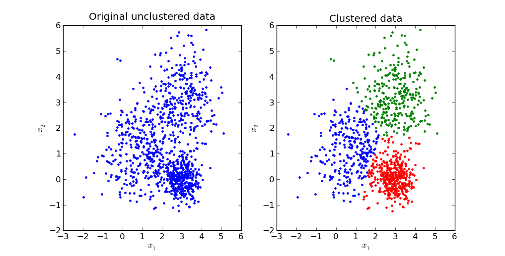

Before and after clustering

Internal Structure?

## What Is A Cluster

Clustering is the grouping of objects according to certain attributes.

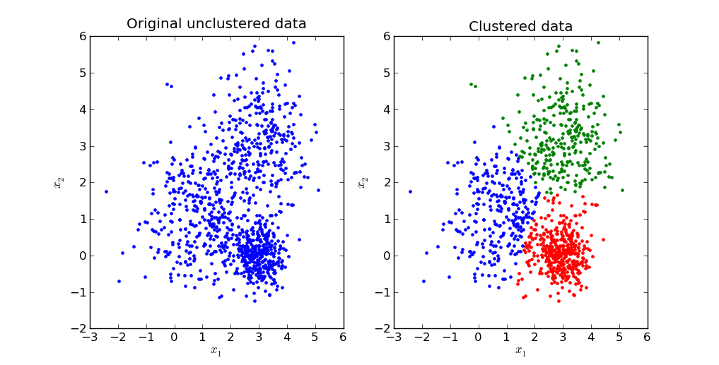

Before and after clustering

## Assignment Function

K means uses the Euclidean distance from the data points to centroids to to assign datapoints to clusters.

\[||\vec{a}|| = \sqrt{\sum_i^n a_i^2} = \sqrt{a_1^2 + a_2^2 + \dots + a_n^2}\]

## Summarizing a cluster

k = number of clusters

k cluster centers (Centroid)

\[\mu_k = (\mu_{k,1},\mu_{k,2},\dots,\mu_{k,d})\]

\[\mu_1,\mu_2,\dots,\mu_k\]

Each cluster will have a set of points S assigned to it

\[S_k = Set\ of\ points\ in\ cluster\ k\]

\[S_1,S_2,\dots,S_k\]

## k means assignment

\[Distance(x_n,\mu_k) = \sqrt{(x_{n,1}-\mu_{k,1})^2+\dots+(x_{n,d}-\mu_{k,d})^2}\]

## Loss Function

\[Distance_{Global} = \sum_{i=1}^k \sum_{n:x_n \in S_k} Distance(x_{n},\mu_{k})^2 \]

\(\sum_{n:x_n \in S_k}\) = for each point in the cluster

\(Distance(x_{n},\mu_{k})^2\) = the sum of the squares of euclidean distance of each points feature to each respective centroid feature

## Steps

-Initialize K clusters

-Repeat untill convergence{

1. Assign each datapoint to the cluster with the clostset centroid

2. Assign each centroid to be the mean of its clusters datapoints.

}

## Pseudocode

Randomly sample k points from dataset without replacement

\[\mu_k\leftarrow x_n\]

- Repeat untill convergence{

1. Assign each datapoint to the cluster with the clostset centroid

2. Assign each centroid to be the mean of its clusters datapoints.

}

## Pseudocode

Randomly sample k points from dataset without replacement

\[\mu_k\leftarrow x_n\]

Repeat untill \(S_1...S_k\) dont change{

1. Assign each datapoint to the cluster with the clostset centroid

2. Assign each centroid to be the mean of its clusters datapoints.

}

## Pseudocode

Randomly sample k points from dataset without replacement

\[\mu_k\leftarrow x_n\]

Repeat untill \(S_1...S_k\) dont change{

-find \(\mu_k\) for \(x_n\) with the smallest \(Distance(\mu_k,x_n)\)

-Place \(x_n\) in Set \(S_k\) and no other \(S_j\)

2.Assign each centroid to be the mean of its clusters datapoints.

}

## Pseudocode

Randomly sample k points from dataset without replacement

\[\mu_k\leftarrow x_n\]

Repeat untill \(S_1...S_k\) dont change{

-find \(\mu_k\) for \(x_n\) with the smallest \(Distance(\mu_k,x_n)\)

-Place \(x_n\) in Set \(S_k\) and no other \(S_j\)

\[\mu_k\leftarrow|S_k|^{-1} = \frac{1}{N}\sum_{n:x_n \in S_k} x_n\]

}

## Evaluation

Calculate Global distance for each final cluster assignment

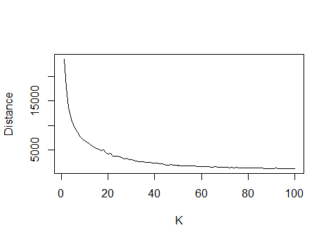

## Watch out

Global vs local minimum

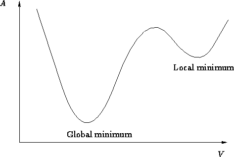

Global minimum vs Local minimum

## test images

[figure not shown]

Global minimum vs Local minimum

## Applications

Dataset Segmentation:

1.Understand data better

2.Reduce a dataset to a centroid set

3.Cluster-then-Predict

## Applications

Image Compression (85kb)

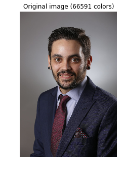

Full Color Image

## Applications

Image Compression (63kb)

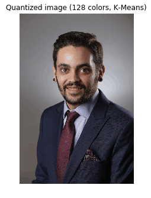

128 Color Image

## Applications

Image Compression (50kb)

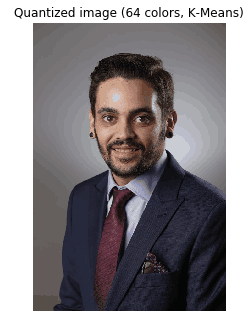

64 Color Image

## Applications

Image Compression (36kb)

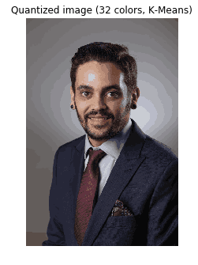

32 Color Image

## Applications

Image Compression (26kb)

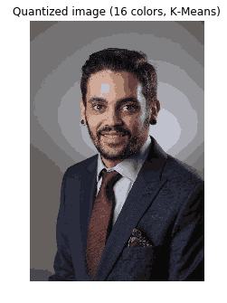

16 Color Image

## Applications

Image Compression (18kb)

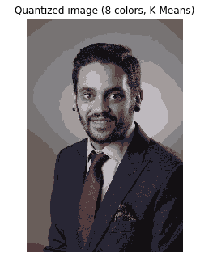

8 Color Image

## Applications

Image Compression (10kb)

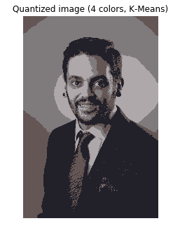

4 Color Image

## Applications

Image Compression (7kb)

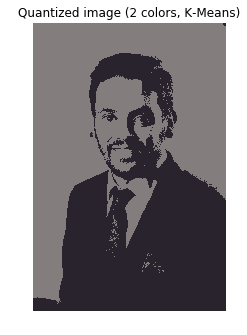

2 Color Image

## App

https://carlos-ordonez.shinyapps.io/k-means_app/

https://github.com/Carlos-Ordonez/K-Means